# Four Degree

2024-01-23

# Introduction

In Melanoma-Associated Retinopathy (MAR), retinal rod bipolar cells internalize anti-TRPM1 autoantibodies, bringing them into their cytosol using an unknown mechanism. This experiment serves as a negative control for evaluating the cellular mechanisms contributing to antibody uptake, as cold temperatures are known to inhibit all forms of endocytosis. Split retinas are equilibrated to and maintained at 37º or 4º during incubation with a PKCa antibody. The expectation is that antibody internalization is significantly reduced or absent in the 4º group compared to the 37º group.

Microscopy data were collected on a Leica SPX8 Confocal microscope. Images were processed in Arivis software using a custom pipeline that quantifies internalized antibody only within rod bipolar cells (segmented based on transgenic Td tomato expression), excluding any dead cells or bright staining artefacts.

Channel guide:

- Channel 1 = Zombie dye
- Channel 2 = Td tomato
- Channel 3 = AF-488 (uptake)
- Channel 4 = DIC

# Data Import and Tidying

**Pipeline Version**: this notebook is updated to process output from Arivis pipeline V4

## Read in the Data

For each individual experiment, there is a separate excel workbook of data generated for every image. These are workbooks are placed into subfolders of the *data* directory. All workbooks from an experiment are imported into a list, then merged into a single data frame with `bind_rows`

Variable names are then cleaned with `janitor` and extraneous columns are excluded (can be retrieved for different analysis later)

The `read_n_clean` function also implements the `condition_select` method, which allows the user to assign treatment conditions (i.e 37 ºC vs 4 ºC) to samples by the name of the sample (i.e “s1.2”)

```r
#e1-450
imgs_37 <- c("s1.2")
imgs_4 <- c("s3.1", "s3.3", "s4.1")
e450 <- read_n_clean(folder_path = "data/e1-450", cond1_vec = imgs_37, cond2_vec = imgs_4, cond1_title = "37 ºC", cond2_title = "4 ºC")

#e1-451
imgs_37 <- c("s1.1", "s1.2", "s1.3", "s2.1", "s2.2", "s2.3")
imgs_4 <- c("s3.1", "s3.2", "s4.1", "s4.3")
e451 <- read_n_clean(folder_path = "data/e1-451", cond1_vec = imgs_37, cond2_vec = imgs_4, cond1_title = "37 ºC", cond2_title = "4 ºC")

#e1-452
imgs_37 <- c("s1.2", "s1.3", "s2.1")
imgs_4 <- c("s3.3","s4.2", "s4.3")
e452 <- read_n_clean(folder_path = "data/e1-452", cond1_vec = imgs_37, cond2_vec = imgs_4, cond1_title = "37 ºC", cond2_title = "4 ºC")

#place all experiment dataframes into a list for batch processing
all_temp_exps <- list("e450" = e450, "e451" = e451, "e452" = e452)
```

# Data Analysis

The “mean_intensities_3” in the dataframe is an average of the signal intensity from channel 3 within a given RBC (segmented by its Td tomato reporter), so this is an individual cell average. We next need to average the signal across all cells on a given piece of tissue. There may be multiple (non-overlapping) images from a given piece of tissue, denoted by the number following the hyphen in the sample name:

s1.2**-1**

Begin by identifying all images that come from the same piece of tissue, using a Regex to identify this based on the sample name

```r
#regex string that will extract everything between the 's' and the '-' in the sample name
sample_string <- "s.*?.?(?=-)"

#add new variable "tissue" that uses the regex to match all images from the same piece of tissue
all_temp_exps <- lapply(all_temp_exps, function(x){mutate(x, tissue = str_extract(x$image_set, pattern = sample_string),.after = 1)})
all_temp_exps[1]
```

```
## $e450
## # A tibble: 18,681 × 9
##    image_set tissue    id min_intensities_3 max_intensities_3 mean_intensities_3
##    <chr>     <chr>  <dbl>             <dbl>             <dbl>              <dbl>
##  1 s1.2-1 -… s1.2       1                 0                15               2.54
##  2 s1.2-1 -… s1.2       2                 0                 7               1.25
##  3 s1.2-1 -… s1.2       3                 0                40               3.84
##  4 s1.2-1 -… s1.2       4                 0                22               5.34
##  5 s1.2-1 -… s1.2       5                 0                 5               1.71
##  6 s1.2-1 -… s1.2       7                 0                45               5.01
##  7 s1.2-1 -… s1.2       8                 0                40               3.65
##  8 s1.2-1 -… s1.2       9                 0                22               3.33
##  9 s1.2-1 -… s1.2      10                 0                79               4.81
## 10 s1.2-1 -… s1.2      11                 0                12               4.47
## # ℹ 18,671 more rows
## # ℹ 3 more variables: sum_intensities_3 <dbl>, volume_volume_um3 <dbl>,
## #   condition <chr>
```

Next, group by `tissue` and average `mean_intensities_3`. Also group by `image_set` and average `mean_intensities_3`

```r
all_temp_exps <- lapply(all_temp_exps, function(x){
  x %>%
    group_by(tissue) %>% #first compute avg grouping by tissue (contains multiple images)
    mutate(tissue_avg = mean(mean_intensities_3)) %>%
    ungroup() %>%
    group_by(image_set) %>%
    mutate(img_avg = mean(mean_intensities_3)) %>%
    ungroup()
  })

all_temp_exps[1]
```

```
## $e450
## # A tibble: 18,681 × 11
##    image_set tissue    id min_intensities_3 max_intensities_3 mean_intensities_3
##    <chr>     <chr>  <dbl>             <dbl>             <dbl>              <dbl>
##  1 s1.2-1 -… s1.2       1                 0                15               2.54
##  2 s1.2-1 -… s1.2       2                 0                 7               1.25
##  3 s1.2-1 -… s1.2       3                 0                40               3.84
##  4 s1.2-1 -… s1.2       4                 0                22               5.34
##  5 s1.2-1 -… s1.2       5                 0                 5               1.71
##  6 s1.2-1 -… s1.2       7                 0                45               5.01
##  7 s1.2-1 -… s1.2       8                 0                40               3.65
##  8 s1.2-1 -… s1.2       9                 0                22               3.33
##  9 s1.2-1 -… s1.2      10                 0                79               4.81
## 10 s1.2-1 -… s1.2      11                 0                12               4.47
## # ℹ 18,671 more rows
## # ℹ 5 more variables: sum_intensities_3 <dbl>, volume_volume_um3 <dbl>,
## #   condition <chr>, tissue_avg <dbl>, img_avg <dbl>
```

Checking to see that each image has a distinct average and each tissue has a distinct average. Looks good

```r
all_temp_exps[[2]] %>%
  group_by(image_set, tissue, condition, tissue_avg, img_avg) %>%
  summarise() %>%
  kbl() %>%
  kable_paper()
```

```
## 'tissue_avg'. You can override using the `.groups` argument.
```

| image_set | tissue | condition | tissue_avg | img_avg |
| --- | --- | --- | --- | --- |
| s1.1-1 - 24-01-29_e1-451.lif | s1.1 | 37 ºC | 33.936158 | 36.578714 |
| s1.1-2 - 24-01-29_e1-451.lif | s1.1 | 37 ºC | 33.936158 | 32.866914 |
| s1.1-3 - 24-01-29_e1-451.lif | s1.1 | 37 ºC | 33.936158 | 31.244933 |
| s1.1-4 - 24-01-29_e1-451.lif | s1.1 | 37 ºC | 33.936158 | 33.973195 |
| s1.2-1 - 24-01-29_e1-451.lif | s1.2 | 37 ºC | 26.374486 | 31.946638 |
| s1.2-2 - 24-01-29_e1-451.lif | s1.2 | 37 ºC | 26.374486 | 25.328609 |
| s1.2-3 - 24-01-29_e1-451.lif | s1.2 | 37 ºC | 26.374486 | 30.068050 |
| s1.2-4 - 24-01-29_e1-451.lif | s1.2 | 37 ºC | 26.374486 | 18.850690 |
| s1.3-1 - 24-01-29_e1-451.lif | s1.3 | 37 ºC | 27.928098 | 27.928098 |
| s2.1-1 - 24-01-29_e1-451.lif | s2.1 | 37 ºC | 21.205410 | 19.549899 |
| s2.1-2 - 24-01-29_e1-451.lif | s2.1 | 37 ºC | 21.205410 | 22.381644 |
| s2.2-1 - 24-01-29_e1-451.lif | s2.2 | 37 ºC | 13.719189 | 13.719189 |
| s2.3-1 - 24-01-29_e1-451.lif | s2.3 | 37 ºC | 11.551827 | 11.551827 |
| s3.1-1 - 24-01-29_e1-451.lif | s3.1 | 4 ºC | 12.112328 | 12.095294 |
| s3.1-2 - 24-01-29_e1-451.lif | s3.1 | 4 ºC | 12.112328 | 12.483186 |
| s3.1-3 - 24-01-29_e1-451.lif | s3.1 | 4 ºC | 12.112328 | 11.779449 |
| s3.2-1 - 24-01-29_e1-451.lif | s3.2 | 4 ºC | 12.873999 | 13.120855 |
| s3.2-2 - 24-01-29_e1-451.lif | s3.2 | 4 ºC | 12.873999 | 12.619703 |
| s4.1-1 - 24-01-29_e1-451.lif | s4.1 | 4 ºC | 6.815407 | 7.420832 |
| s4.1-2 - 24-01-29_e1-451.lif | s4.1 | 4 ºC | 6.815407 | 6.498756 |
| s4.1-3 - 24-01-29_e1-451.lif | s4.1 | 4 ºC | 6.815407 | 6.527186 |
| s4.3-1 - 24-01-29_e1-451.lif | s4.3 | 4 ºC | 8.408893 | 8.408893 |

Merge all dataframes in list into one dataframe

```r
all_temp_exps <- bind_rows(all_temp_exps, .id = "exp") %>%
  mutate(exp = as.factor(exp))
```

When plotting, each piece of tissue (tissue average) will be a point. The bar will be the *condition average* and will be made after merging all experiments into a single dataframe.

```r
all_temp_exps <- all_temp_exps %>%
    group_by(condition) %>%
    mutate(condition_avg = mean(tissue_avg),
           condition_sd = sd(tissue_avg)) %>%
    ungroup()


#all_temp_exps
```

# Statistics

Data includes one continuous outcome variable (uptake signal intensity), one categorical predictor variable (treatment condition). If the data are normally distributed, then significant difference between groups can be assessed using an `independent t test (unpaired)`

## Shapiro-Wilk Normality test

- try performing on every individual data point: `mean_intensities_3`
- try performing on just what goes into the plot: `tissue_avg`

Histogram on points to be plotted

```
## 'tissue_avg', 'condition_sd'. You can override using the `.groups` argument.
```

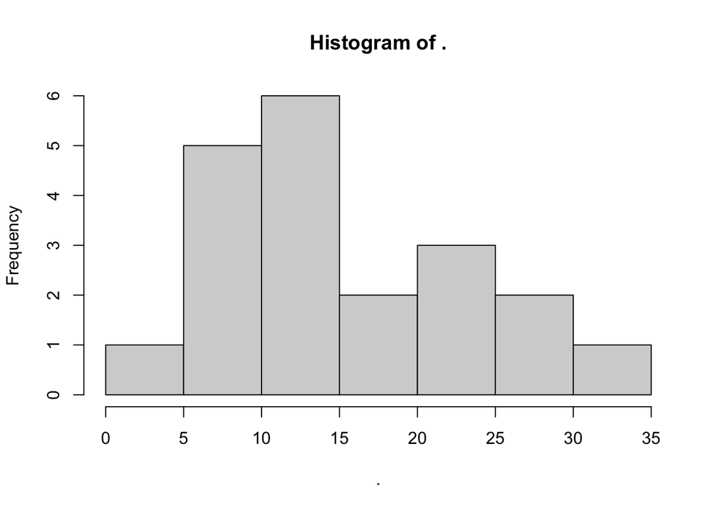

```r
all_temp_exps %>%
  group_by(tissue, condition, condition_avg, tissue_avg, condition_sd, exp) %>%
  summarise() %>%
  pull(tissue_avg) %>%
  hist()
```

Shapiro-Wilk on points to be plotted

```r
shapiro_result <- all_temp_exps %>%
  group_by(tissue, condition, condition_avg, tissue_avg, condition_sd, exp) %>%
  summarise() %>%
  pull(tissue_avg) %>%
  shapiro.test()
```

```
## 'tissue_avg', 'condition_sd'. You can override using the `.groups` argument.
```

```r
if(shapiro_result$p.value > 0.05){
  print(c("The p-value of the Shapiro-Wilks test = ", as.character(shapiro_result$p.value), ". For alpha = 0.05, the data are normally distributed"))
}
```

```
## [1] "The p-value of the Shapiro-Wilks test = "
## [2] "0.14608979851211"
## [3] ". For alpha = 0.05, the data are normally distributed"
```

```r
if(shapiro_result$p.value < 0.05){
  print(c("The p-value of the Shapiro-Wilks test = ", as.character(shapiro_result$p.value), ". For alpha = 0.05, the data are NOT normally distributed"))
}
```

## Un-paired T-test

Performing a Welch’s t-test since this does not assume the variance in the two groups is the same.

```r
temp_t_test <- all_temp_exps %>%
  group_by(tissue, condition, condition_avg, tissue_avg, condition_sd, exp) %>%
  summarise() %>% #the group by and summarize lines are to filter to only the data that will be plotted and was tested in the normality test
  ungroup() %>%
  t_test(tissue_avg ~ condition) %>%
  add_significance() %>%
  add_xy_position(x = "condition")
```

```
## 'tissue_avg', 'condition_sd'. You can override using the `.groups` argument.
```

```r
temp_t_test
```

```
## # A tibble: 1 × 13
##   .y.      group1 group2    n1    n2 statistic    df       p p.signif y.position
##   <chr>    <chr>  <chr>  <int> <int>     <dbl> <dbl>   <dbl> <chr>         <dbl>
## 1 tissue_… 37 ºC  4 ºC      10    10      4.59  12.9 5.14e-4 ***            36.2
## # ℹ 3 more variables: groups <named list>, xmin <dbl>, xmax <dbl>
```

# Plotting

```r
temp_plot <- uptake_plot(all_temp_exps, output_name = "all_temp_exps_V4.1", condition_label = "Incubation Temperature", add_stats = TRUE, temp_t_test)
```

```
## 'tissue_avg', 'condition_sd'. You can override using the `.groups` argument.
```

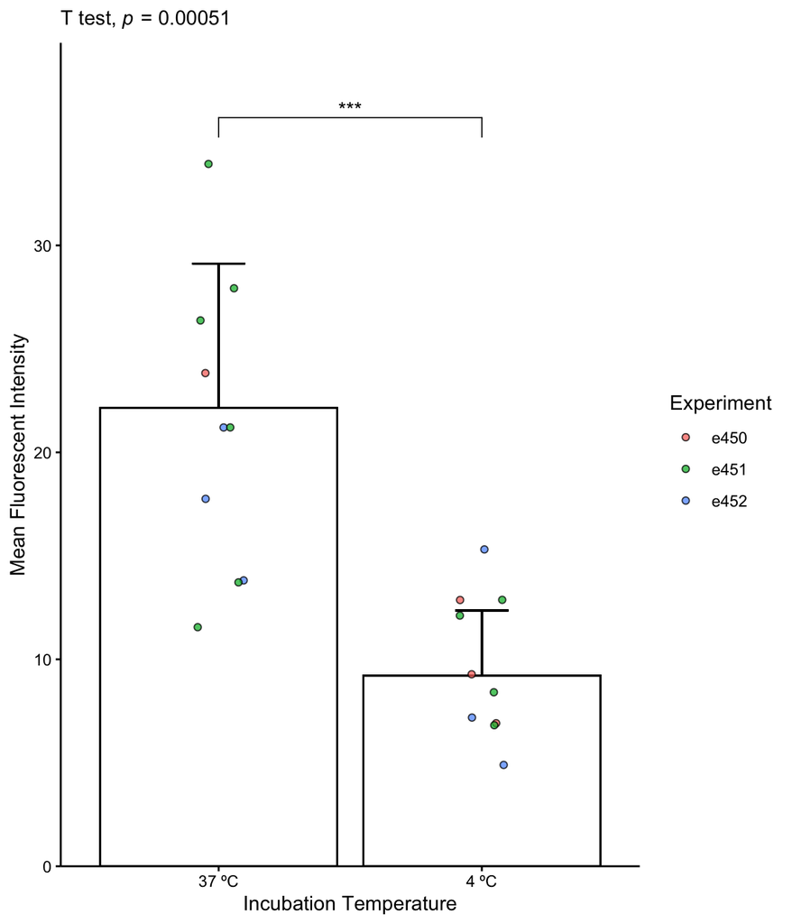

```r
temp_plot
```

Table of the plotted values

```r
all_temp_exps %>%
  group_by(tissue, condition, condition_avg, tissue_avg, condition_sd, exp) %>%
  summarise() %>%
  kbl() %>%
  kable_paper()
```

```
## 'tissue_avg', 'condition_sd'. You can override using the `.groups` argument.
```

| tissue | condition | condition_avg | tissue_avg | condition_sd | exp |
| --- | --- | --- | --- | --- | --- |
| s1.1 | 37 ºC | 22.145694 | 33.936158 | 6.969350 | e451 |
| s1.2 | 37 ºC | 22.145694 | 21.203453 | 6.969350 | e452 |
| s1.2 | 37 ºC | 22.145694 | 23.831400 | 6.969350 | e450 |
| s1.2 | 37 ºC | 22.145694 | 26.374486 | 6.969350 | e451 |
| s1.3 | 37 ºC | 22.145694 | 13.813318 | 6.969350 | e452 |
| s1.3 | 37 ºC | 22.145694 | 27.928098 | 6.969350 | e451 |
| s2.1 | 37 ºC | 22.145694 | 17.753417 | 6.969350 | e452 |
| s2.1 | 37 ºC | 22.145694 | 21.205410 | 6.969350 | e451 |
| s2.2 | 37 ºC | 22.145694 | 13.719189 | 6.969350 | e451 |
| s2.3 | 37 ºC | 22.145694 | 11.551827 | 6.969350 | e451 |
| s3.1 | 4 ºC | 9.202523 | 6.911128 | 3.157324 | e450 |
| s3.1 | 4 ºC | 9.202523 | 12.112328 | 3.157324 | e451 |
| s3.2 | 4 ºC | 9.202523 | 12.873999 | 3.157324 | e451 |
| s3.3 | 4 ºC | 9.202523 | 9.276894 | 3.157324 | e450 |
| s3.3 | 4 ºC | 9.202523 | 15.309888 | 3.157324 | e452 |
| s4.1 | 4 ºC | 9.202523 | 6.815407 | 3.157324 | e451 |
| s4.1 | 4 ºC | 9.202523 | 12.867453 | 3.157324 | e450 |
| s4.2 | 4 ºC | 9.202523 | 7.185932 | 3.157324 | e452 |
| s4.3 | 4 ºC | 9.202523 | 4.897045 | 3.157324 | e452 |
| s4.3 | 4 ºC | 9.202523 | 8.408893 | 3.157324 | e451 |

## Exploring data further

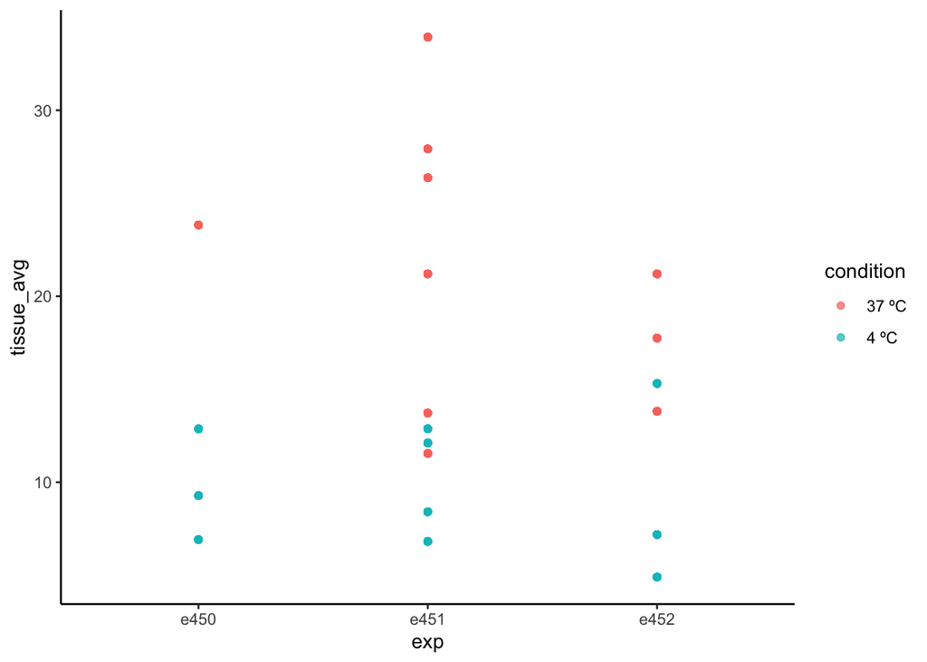

```r
all_temp_exps %>%
  ggplot()+
  geom_point(aes(x = exp, y = tissue_avg, color = condition), alpha = 0.7)+
  theme_classic()
```